# practical_exercise_5, Methods 3, 2021, autumn semester

Mie Buchhave Søgaard

27.10.2021

# Exercises and objectives

The objectives of the exercises of this assignment are based on: https://doi.org/10.1016/j.concog.2019.03.007

4. Download and organise the data from experiment 1
5. Use log-likelihood ratio tests to evaluate logistic regression models
6. Test linear hypotheses
7. Estimate psychometric functions for the Perceptual Awareness Scale and evaluate them

## Exercise 4 - Download and organise data from experiment 1

Data from: https://osf.io/ecxsj/files/ The data is associated with Experiment 1 of the article at the following DOI https://doi.org/10.1016/j.concog.2019.03.007

#### 1) Put the data from all subjects into a single data frame - note that some of the subjects do not have the *seed* variable. For these subjects, add this variable and make in *NA* for all observations. (The *seed* variable will not be part of the analysis and is not an experimental variable)

**i. Factorize the variables that need factorizing**  
**ii. Remove the practice trials from the dataset** **iii. Create a *correct* variable** **iv. Describe how the *target.contrast* and *target.frames* variables differ compared to the data from part 1 of this assignment**

```r
# reading data (read_bulk automatically adds NA for all observations that does not have the seed variable)
df <- read_bulk(directory = "experiment_1",
                           fun = read_csv)
df <- df %>%
  filter(trial.type != 'practice') # removing practice trials (i.e. keeping experiment trials)

df$correct <- as.factor(ifelse((df$target.type == "odd" & df$obj.resp == "o") | (df$target.type == "even" & df$obj.resp == "e"), 1, 0))

# Only changing variables that are used in the analysis
df$pas <- as.factor(df$pas)
df$cue <- as.factor(df$cue)
df$even.digit <- as.factor(df$even.digit)
df$odd.digit <- as.factor(df$odd.digit)
df$obj.resp <- as.factor(df$obj.resp)
df$subject <- as.numeric(df$subject) # for analysis later
df$subject <- as.factor(df$subject)
df$trial <- as.integer(df$trial)
df$target.frames <- as.integer(df$target.frames)
```

The *target.contrast* in experiment 1 stays the same throughout all trials (0.1), while *target.contrast* in experiment 2 changes throughout trials. Opposite, *target.frames* in experiment 1 differs by alternating between 1 and 6 target frames during trials, whereas target frames in experiment 2 is consistent (3 through all trials).

## EXERCISE 5 - Use log-likelihood ratio tests to evaluate logistic regression models

#### 1) Do logistic regression - *correct* as the dependent variable and *target.frames* as the independent variable. (Make sure that you understand what *target.frames* encode). Create two models - a pooled model and a partial-pooling model. The partial-pooling model should include a subject-specific intercept.

```r
glm.pool <- glm(correct ~ target.frames, data = df, family = 'binomial')

glm.part.pool <- lme4::glmer(correct ~ target.frames + (1 | subject), data = df, family = 'binomial')
```

**i. The likelihood-function for logistic regression is: $L(p)={\displaystyle\prod_{i=1}^Np^{y_i}(1-p)^{(1-y_i)}}$. Create a function that calculates the likelihood.**

```r
# Function that calculates the likelihood

my.likelihood <- function(p, y) {
  a <- c()
  n <- length(p)
   for(i in 1:n) {
     a[i] <-  p[i]**(y[i])*(1-p[i])**((1-y[i]))
   }
  print(prod(a))
}
```

ii. The log-likelihood-function for logistic regression is: $l(p) = {\displaystyle\sum_{i=1}^N}[y_i\ln{p}+(1-y_i)\ln{(1-p)}$.  
Create a function that calculates the log-likelihood

```r
# Function that calculates the log-likelihood
my.log.likelihood <- function(p, y) {
  a <- c()
  n <- length(p)
   for(i in 1:n) {
     a[i] <- y[i]*log(p[i])+(1-y[i])*log(1-p[i])
   }
  print(sum(a))
}
```

**iii. Apply both functions to the pooling model you just created. Make sure that the log-likelihood matches what is returned from the *logLik* function for the pooled model. Does the likelihood-function return a value that is surprising? Why is the log-likelihood preferable when working with computers with limited precision?**

```r
inv.logit <- function(x) exp(x) / (1 + exp(x))
```

```r
# p = fitted values
# y = actual values

y <- as.integer(df$correct)-1
p <- fitted.values(glm.pool)
p.inv <- inv.logit(fitted.values(glm.pool))

# Likelihood
my.likelihood(p.inv, y)
```

```
## [1] 0
```

```r
# LogLik function
my.log.likelihood(p, y)
```

```
## [1] -10865.25
```

```r
# LogLik from model
logLik(glm.pool)
```

```
## 'log Lik.' -10865.25 (df=2)
```

To match the return from the model, we do not take the inverse logit of the fitted values. We need to work with the log odds values here in order to find the log-likelohood. The likelihood returns a zero, which is not that surprising as we can resonate that the likelihood of getting the exact same 25,044 results again is very low. And the return of zero shows that the likelihood is lower than what the computer have computational power to calculate Said in another way, products are not numerically stable, as they tend to converge quickly to zero or to infinity. From a numerical standpoint, sums are more stable, and this is crucial because the maximum likelihood problem is often solved numerically on computers where limited precision is not able to distinguish a very small number from zero and a very large number from infinity. Thus, the log-likelihood is therefore preferable when working with computers with limited precision, as it returns the log-odds of the probability, which is a more numerically stable number.

**iv. Now show that the log-likelihood is a little off when applied to the partial pooling model**

```r
y <- as.integer(df$correct)-1
p <- fitted.values(glm.part.pool)

my.log.likelihood(p, y)
```

```
## [1] -10565.53
```

```r
logLik(glm.part.pool)
```

```
## 'log Lik.' -10622.03 (df=3)
```

#### 2) Use log-likelihood ratio tests to argue for the addition of predictor variables, start from the null model, `glm(correct ~ 1, 'binomial', data)`, then add subject-level intercepts, then add a group-level effect of *target.frames* and finally add subject-level slopes for *target.frames*. Also assess whether or not a correlation between the subject-level slopes and the subject-level intercepts should be included.

```r
model.2.null <- glm(correct ~ 1, data = df, family = 'binomial')

model.2.int <- lme4::glmer(correct ~ 1 + (1 | subject), data = df, family = 'binomial')

model.2.group <- lme4::glmer(correct ~ target.frames + (1 | subject), data = df, family = 'binomial')

model.2.slope <- lme4::glmer(correct ~ target.frames + (1 + target.frames | subject), data = df, family = 'binomial')

model.2.no_cor <- lme4::glmer(correct ~ target.frames + (1 + target.frames || subject), data = df, family = 'binomial')
```

```r
VarCorr(model.2.slope)
```

```
##  Groups  Name          Std.Dev. Corr
##  subject (Intercept)   0.24669
##          target.frames 0.22620  -0.870
```

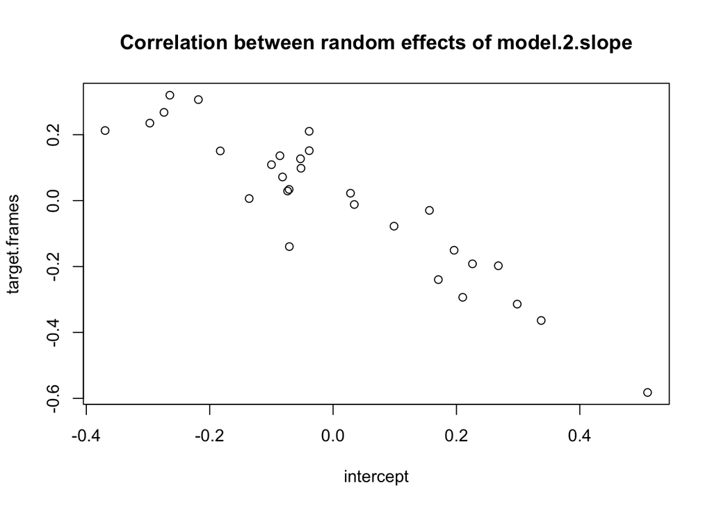

```r
m4.data <- ranef(model.2.slope)

for (i in seq(m4.data)){
  assign(paste0("m4.data", i), m4.data[[i]])
}

colnames(m4.data1) <- c("Intercept", "target.frames")

#We now plot the correlation between the random effects of intercept and slope.
plot(m4.data1$Intercept, m4.data1$target.frames, ylab="target.frames", xlab="intercept", main="Correlation between random effects of model.2.slope")
```

```r
# Model with correlation between subject-level slope and subject-level intercept
loglik1 <- logLik(model.2.slope)

# Model without correlation between subject-level slope and subject-level intercept
loglik2 <- logLik(model.2.no_cor)

AICs <- AIC(model.2.no_cor, model.2.slope)

tibble("Model: subject-level ..."=c("... including correlation", "... excluding correlation"),
       "LogLik" = c(loglik1, loglik2),
       "AIC" = c(AICs[2,2], AICs[1,2]))
```

| Model: subject-level ... | LogLik | AIC |
| --- | --- | --- |
| ... including correlation | -10448.83 | 20907.65 |
| ... excluding correlation | -10460.29 | 20928.58 |

```r
# running af log-likelihood ratio test
anova(model.2.slope, model.2.group, model.2.int, model.2.null)
```

|  | npar | AIC | BIC | logLik | deviance | Chisq | Df | Pr(>Chisq) |
| --- | --- | --- | --- | --- | --- | --- | --- | --- |
| model.2.null | 1 | 26685.08 | 26693.21 | -13341.54 | 26683.08 | NA | NA | NA |
| model.2.int | 2 | 26319.10 | 26335.35 | -13157.55 | 26315.10 | 367.9798 | 1 | 5.153061e-82 |
| model.2.group | 3 | 21250.06 | 21274.45 | -10622.03 | 21244.06 | 5071.0352 | 1 | 0.000000e+00 |
| model.2.slope | 5 | 20907.65 | 20948.29 | -10448.83 | 20897.65 | 346.4127 | 2 | 5.990142e-76 |

**i. Write a short methods section and a results section where you indicate which model you chose and the statistics relevant for that choice. Include a plot of the estimated group-level function with `xlim=c(0, 8)` that includes the estimated subject-specific functions.**  
**ii. also include in the results section whether the fit didn’t look good for any of the subjects. If so, identify those subjects in the report, and judge (no statistical test) whether their performance (accuracy) differed from that of the other subjects. Was their performance better than chance? (Use a statistical test this time) (50 %)**

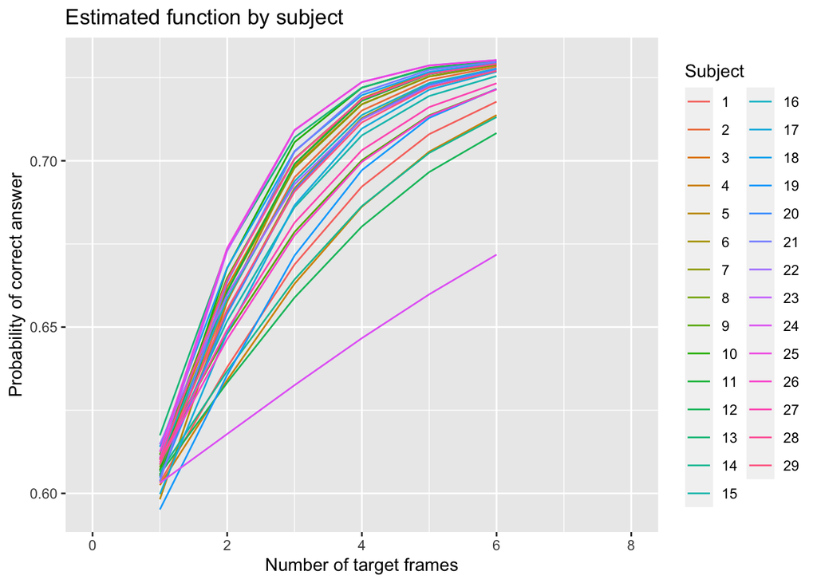

```r
new_df <- cbind(df, fitted = fitted(model.2.slope), probabilities = inv.logit(fitted(model.2.slope)))

ggplot(new_df, aes(x = target.frames, y = probabilities, color = subject)) +
  geom_line() +
  xlim(0, 8) +
  labs(x = "Number of target frames",
       y = "Probability of correct answer",
       title = "Estimated function by subject") +
  scale_color_discrete(name = "Subject")
```

```r
# binomial test for subject 24
sub24 <- new_df %>%
  filter(subject == '24')

table(sub24$correct) # extracting number of correct and incorrect answers
```

```
##
##   0   1
## 378 496
```

```r
vector <- c(496, 378) # making a vector with the length of 2 (number of correct and incorrect answers, respectively)

binom.test(vector, p = 0.5)
```

```
##
##  Exact binomial test
##
## data:  vector
## number of successes = 496, number of trials = 874, p-value = 7.397e-05
## alternative hypothesis: true probability of success is not equal to 0.5
## 95 percent confidence interval:
##  0.5339074 0.6006475
## sample estimates:
## probability of success
##              0.5675057
```

Logistic regression was used to analyze the whether the number of target frames affects the on the probability of answering correctly. It was found that the probability of getting a correct answer increases significantly by 69,7% for each increase of 1 target frame, β = 0.83317, SE = 0.04433 *p* < .001.

Looking at the plot, we can observe that the fit does not look good for subject 24. The subject seems to have lower accuracy compared to the other subjects, and so it is judged that this person’s performance differs (negatively) from the others. The binomial test revealed that subject 24’s performance was better than chance, and also significantly different from chance (set to 50%). However, accuracy is around 57%, which is not far from chance.

#### 3) Now add *pas* to the group-level effects - if a log-likelihood ratio test justifies this, also add the interaction between *pas* and *target.frames* and check whether a log-likelihood ratio test justifies this**

**i. If your model doesn’t converge, try a different optimizer**

```r
model.3.frames.pas <- lme4::glmer(correct ~ target.frames + pas + (1 + target.frames | subject), data = df, family = 'binomial')
```

```r
model.3.frames.pas.interaction <- lme4::glmer(correct ~ target.frames*pas + (1 + target.frames | subject), data = df, family = 'binomial')
```

```r
# Log-likelihood ratio test
anova(model.3.frames.pas.interaction, model.3.frames.pas, model.2.slope)
```

|  | npar | AIC | BIC | logLik | deviance | Chisq | Df | Pr(>Chisq) |
| --- | --- | --- | --- | --- | --- | --- | --- | --- |
| model.2.slope | 5 | 20907.65 | 20948.29 | -10448.825 | 20897.65 | NA | NA | NA |
| model.3.frames.pas | 8 | 19879.66 | 19944.68 | -9931.828 | 19863.66 | 1033.9934 | 3 | 7.599679e-224 |
| model.3.frames.pas.interaction | 11 | 19506.08 | 19595.49 | -9742.039 | 19484.08 | 379.5781 | 3 | 5.866736e-82 |

**ii. Plot the estimated group-level functions over `xlim=c(0, 8)` for each of the four PAS-ratings - add this plot to your report (see: 5.2.i) and add a description of your chosen model. Describe how *pas* affects accuracy together with target duration if at all. Also comment on the estimated functions’ behaviour at target.frame=0 - is that behaviour reasonable?**

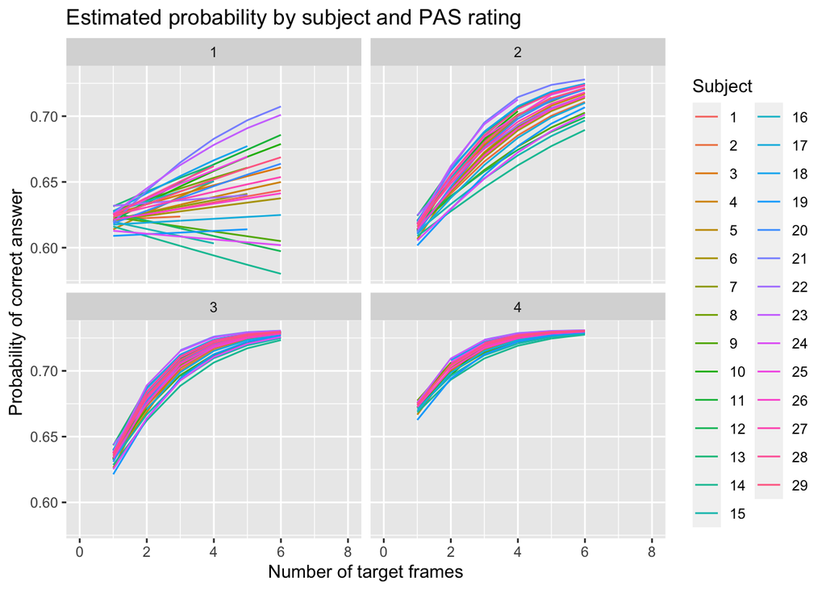

```r
new_df <- cbind(df, fitted = fitted(model.3.frames.pas.interaction), probabilities = inv.logit(fitted(model.3.frames.pas.interaction)))


ggplot(new_df, aes(x = target.frames, y = probabilities, color = subject)) +
  geom_line() +
  xlim(0, 8) +
  labs(x = "Number of target frames",
       y = "Probability of correct answer",
       title = "Estimated probability by subject and PAS rating") +
  scale_color_discrete(name = "Subject") +
  facet_wrap(~pas)
```

From the output we can observe that the Chi-Squared test-statistic for model 3 with interaction is 379.58. *p* < 0.05. Thus, adding the interaction seem offer a significant improvement in fit, and the chosen model is therefore the model with the interaction between *target.frames* and *pas*.

When rating PAS 1 (not seeing the target clearly), the number og target frames does not really seem to have any systematic effect on accuracy. For PAS rating 2, 3 and 4, we see a more systematic pattern, where an increase of target frames increases the accuracy. For PAS rating 2, there seem to be a more linear relation between target frames and accuracy, whereas for PAS rating 3 and 4 there seems to be a more logarithmic growth, where the increase gets lower as the number of target frames increases. In addition, it is seen that as an increase of PAS rating, there is a corresponding decrease in the variance of the accuracy for each subject. This can be due to the fact that a PAS rating of 4 indicates that the subjects has seen the target very clearly, and therefore the number of target frames does not really have the same impact on accuracy as it has when the subject has indicated a PAS rating of 2-3 (not seeing the target totally clearly). Therefore, the number of target frames has a greater impact on accuracy when the subject has not seen the target very clearly.

Regarding the estimated functions’ behavior at *target.frames* = 0, the behavior can not be seen as reasonable. When not being presented for any target and having two options, the chance for choosing correctly should conceptually not go below 50%. For PAS 1 and 4, the probability of choosing correct is around 50%. At first look, these might seem reasonable, as these estimates are close to chance (as the subject has two options; one being correct and the other one incorrect). However, when looking at *target.frames* = 0 for PAS 2 and 3, we see that the model predicts a probability of correct around 33%-34%, which does not make any conceptual sense. Therefore, it becomes clear that the model does not take the logic of chance into account, and thus it continues below 50%. Even though PAS 1 and 4 is estimates a accuracy close to chance, these estimates does not reflect any underlying reasoning of the statistical model, but rather it seems to be a mathematical happenstance that the model output of *target.frames* = 0 is close to 50%.

## EXERCISE 6 - Test linear hypotheses

In this section we are going to test different hypotheses. We assume that we have already proved that more objective evidence (longer duration of stimuli) is sufficient to increase accuracy in and of itself and that more subjective evidence (higher PAS ratings) is also sufficient to increase accuracy in and of itself.

We want to test a hypothesis for each of the three neighbourghing differences in PAS, i.e. the difference between 2 and 1, the difference between 3 and 2 and the difference between 4 and 3. More specifically, we want to test the hypothesis that accuracy increases faster with objective evidence if subjective evidence is higher at the same time, i.e. we want to test for an interaction.

#### 1) Fit a model based on the following formula: `correct ~ pas * target.frames + (target.frames | subject))`

**i. First, use `summary` (yes, you are allowed to!) to argue that accuracy increases faster with objective evidence for PAS 2 than for PAS 1.**

```r
pas.intact.tf.ranslopeint.with.corr <- glmer(correct ~ pas * target.frames + (target.frames | subject), data = df, family = 'binomial')

summary(pas.intact.tf.ranslopeint.with.corr)
```

```
## Generalized linear mixed model fit by maximum likelihood (Laplace
##   Approximation) [glmerMod]
##  Family: binomial  ( logit )
## Formula: correct ~ pas * target.frames + (target.frames | subject)
##    Data: df
##
##      AIC      BIC   logLik deviance df.resid
##  19506.1  19595.5  -9742.0  19484.1    25033
##
## Scaled residuals:
##      Min       1Q   Median       3Q      Max
## -19.0110   0.0537   0.1606   0.4849   1.4465
##
## Random effects:
##  Groups  Name          Variance Std.Dev. Corr
##  subject (Intercept)   0.03698  0.1923
##          target.frames 0.02057  0.1434   -0.76
## Number of obs: 25044, groups:  subject, 29
##
## Fixed effects:
##                    Estimate Std. Error z value Pr(>|z|)
## (Intercept)        -0.12163    0.06416  -1.896 0.058008 .
## pas2               -0.57140    0.08943  -6.389 1.67e-10 ***
## pas3               -0.53848    0.13956  -3.859 0.000114 ***
## pas4                0.20156    0.25059   0.804 0.421216
## target.frames       0.11480    0.03709   3.095 0.001966 **
## pas2:target.frames  0.44719    0.03475  12.869  < 2e-16 ***
## pas3:target.frames  0.74869    0.04595  16.293  < 2e-16 ***
## pas4:target.frames  0.75928    0.06850  11.084  < 2e-16 ***
## ---
## Signif. codes:  0 '***' 0.001 '**' 0.01 '*' 0.05 '.' 0.1 ' ' 1
##
## Correlation of Fixed Effects:
##             (Intr) pas2   pas3   pas4   trgt.f ps2:t. ps3:t.
## pas2        -0.462
## pas3        -0.308  0.248
## pas4        -0.174  0.121  0.092
## target.frms -0.811  0.306  0.208  0.124
## ps2:trgt.fr  0.482 -0.874 -0.245 -0.124 -0.428
## ps3:trgt.fr  0.393 -0.279 -0.891 -0.112 -0.359  0.371
## ps4:trgt.fr  0.276 -0.163 -0.121 -0.918 -0.260  0.225  0.200
```

We see that the interaction is positive (pas2:target.frames = 0.44719) and significant, *p* < .05, which indicates a steeper increase of target frames in PAS 2 than PAS 1. Thus, accuracy increases faster with objective evidence for PAS 2 than for PAS 1.

#### 2) `summary` won’t allow you to test whether accuracy increases faster with objective evidence for PAS 3 than for PAS 2 (unless you use `relevel`, which you are not allowed to in this exercise). Instead, we’ll be using the function `glht` from the `multcomp` package

**i. To redo the test in 6.1.i, you can create a *contrast* vector. This vector will have the length of the number of estimated group-level effects and any specific contrast you can think of can be specified using this.**

```r
### Snippet for 6.2.i
## testing whether PAS 2 is different from PAS 1
contrast.vector <- matrix(c(0, 0, 0, 0, 0, 1, 0, 0), nrow=1)

gh_i <- glht(pas.intact.tf.ranslopeint.with.corr, contrast.vector)
print(summary(gh_i))
```

[output not shown]

**ii. Now test the hypothesis that accuracy increases faster with objective evidence for PAS 3 than for PAS 2.**

```r
# We set the interaction for pas2:target.frames as our intercept, therefore number 6 is set to -1 (this interaction is number 6 on the Fixed Effects list in 6.1.i)
# We want to compare it to pas3:target.frames, therefore number 7 is set to 1.
contrast.vector <- matrix(c(0, 0, 0, 0, 0, -1, 1, 0), nrow=1)
gh_ii <- glht(pas.intact.tf.ranslopeint.with.corr, contrast.vector)
print(summary(gh_ii))
```

```
##
##   Simultaneous Tests for General Linear Hypotheses
##
## Fit: glmer(formula = correct ~ pas * target.frames + (target.frames |
##     subject), data = df, family = "binomial")
##
## Linear Hypotheses:
##        Estimate Std. Error z value Pr(>|z|)
## 1 == 0  0.30150    0.04621   6.524 6.85e-11 ***
## ---
## Signif. codes:  0 '***' 0.001 '**' 0.01 '*' 0.05 '.' 0.1 ' ' 1
## (Adjusted p values reported -- single-step method)
```

```r
# Comparing it to the estimate from the fixed effects (subtracting the two fixed effects)
fixef(pas.intact.tf.ranslopeint.with.corr)[7]-fixef(pas.intact.tf.ranslopeint.with.corr)[6]
```

```
## pas3:target.frames
##          0.3014988
```

```r
# We see that we get the same number
```

It looks like that accuracy increases significantly faster with objective evidence for PAS 3 than for PAS 2, $\beta$ = 0.302, *p* < .001

**iii. Also test the hypothesis that accuracy increases faster with objective evidence for PAS 4 than for PAS 3**

```r
contrast.vector <- matrix(c(0, 0, 0, 0, 0, 0, -1, 1), nrow=1) # setting PAS 3 as base and comparing to PAS 4
gh_iii <- glht(pas.intact.tf.ranslopeint.with.corr, contrast.vector)
print(summary(gh_iii))
```

```
##
##   Simultaneous Tests for General Linear Hypotheses
##
## Fit: glmer(formula = correct ~ pas * target.frames + (target.frames |
##     subject), data = df, family = "binomial")
##
## Linear Hypotheses:
##        Estimate Std. Error z value Pr(>|z|)
## 1 == 0  0.01060    0.07445   0.142    0.887
## (Adjusted p values reported -- single-step method)
```

Accuracy does not increase significantly faster with objective evidence for PAS 4 than for PAS 3, $\beta$ = 0.011, *p* > .05.

#### 3) Finally, test whether the difference between PAS 2 and 1 (tested in 6.1.i) is greater than the difference between PAS 4 and 3 (tested in 6.2.iii)

```r
contrast.vector <- matrix(c(0, 0, 0, 0, 0, 1, -1, 1), nrow=1)

gh_3 <- glht(pas.intact.tf.ranslopeint.with.corr, contrast.vector)

print(summary(gh_3))
```

```
##
##   Simultaneous Tests for General Linear Hypotheses
##
## Fit: glmer(formula = correct ~ pas * target.frames + (target.frames |
##     subject), data = df, family = "binomial")
##
## Linear Hypotheses:
##        Estimate Std. Error z value Pr(>|z|)
## 1 == 0  0.45778    0.08148   5.618 1.93e-08 ***
## ---
## Signif. codes:  0 '***' 0.001 '**' 0.01 '*' 0.05 '.' 0.1 ' ' 1
## (Adjusted p values reported -- single-step method)
```

The difference between PAS 2 and 1 is greater than the difference between PAS 4 and 3.

## Exercise 7 - Estimate psychometric functions for the Perceptual Awareness Scale and evaluate them

*We saw in 5.3 that the estimated functions went below chance at a target duration of 0 frames (0 ms). This does not seem reasonable, so we will be trying a different approach for fitting here.*

We will fit the following function that results in a sigmoid, $f(x) = a + \frac {b - a} {1 + e^{\frac {c-x} {d}}}$

It has four parameters:  
*a* : the minimum accuracy level  
*b* : the maximum accuracy level  
*c* : the so-called inflexion point (i.e. where the derivative of the sigmoid reaches its maximum)  
*d* : the steepness at the inflexion point

We can define a function of a residual sum of squares as below

```r
my_rss_function <- function(dataset, par) {
    ## "dataset" should be a data.frame containing the variables x (target.frames) and y (correct)
    x <- dataset$x
    y <- dataset$y
    ## "par" are our four parameters (a numeric vector)
    ## par[1]=a, par[2]=b, par[3]=c, par[4]=d
    y.hat <- par[1] + (par[2]-par[1]) / (1+exp((par[3]-x)/par[4]))
    RSS <- sum((y - y.hat)^2)
    return(RSS)
}
```

#### 1) Now, we will fit the sigmoid for the four PAS ratings for Subject 7

**i. Use the function `optim` (with the listed arguments). It returns a list that among other things contains the four estimated parameters.**

```r
dataset <- data.frame(subject = df$subject, x = df$target.frames, y = as.integer(df$correct)-1, pas = df$pas)
```

```r
# Make a dataset for each PAS
dataset.p1 <- dataset %>%
  filter(pas == 1)
dataset.p2 <- dataset %>%
  filter(pas == 2)
dataset.p3 <- dataset %>%
  filter(pas == 3)
dataset.p4 <- dataset %>%
  filter(pas == 4)

# Defining function including optim function
my_optim <- function(my_data) {
  optim(par = c(0.5, 1, 1, 1),
                      fn = my_rss_function,
                      data = my_data,
                      method = c("L-BFGS-B"),
                      lower = c(0.5, 0.5, -Inf, -Inf),
                      upper = c(1 ,1, Inf, Inf)
                      )
}

optim_output.1 <- my_optim(dataset.p1)
optim_output.2 <- my_optim(dataset.p2)
optim_output.3 <- my_optim(dataset.p3)
optim_output.4 <- my_optim(dataset.p4)

# Extracting parameters
par.1 <- optim_output.1$par
par.2 <- optim_output.2$par
par.3 <- optim_output.3$par
par.4 <- optim_output.4$par

dataset.sub7.p1 <- dataset.p1 %>%
  filter(subject == 7)

dataset.sub7.p2 <- dataset.p2 %>%
  filter(subject == 7)

dataset.sub7.p3 <- dataset.p3 %>%
  filter(subject == 7)

dataset.sub7.p4 <- dataset.p4 %>%
  filter(subject == 7)

sub7.p1.x <- dataset.sub7.p1$x
sub7.p2.x <- dataset.sub7.p2$x
sub7.p3.x <- dataset.sub7.p3$x
sub7.p4.x <- dataset.sub7.p4$x

y_hat_fun <- function(x, par) {
  result <- par[1] + (par[2]-par[1]) / (1+exp((par[3]-x)/par[4]))
  return(result)
}

y.hat.p1 <- y_hat_fun(sub7.p1.x, par.1)
y.hat.p2 <- y_hat_fun(sub7.p2.x, par.2)
y.hat.p3 <- y_hat_fun(sub7.p3.x, par.3)
y.hat.p4 <- y_hat_fun(sub7.p4.x, par.4)
```

It has been chosen to set *a* to 0.5, as the model should not go below chance (50%). *b* is set to 1, as the model neither should not exeed a probability of 1 (Thus, min = 0.5 and max = 1).

**ii. Plot the fits for the PAS ratings on a single plot (for subject 7) `xlim=c(0, 8)`**

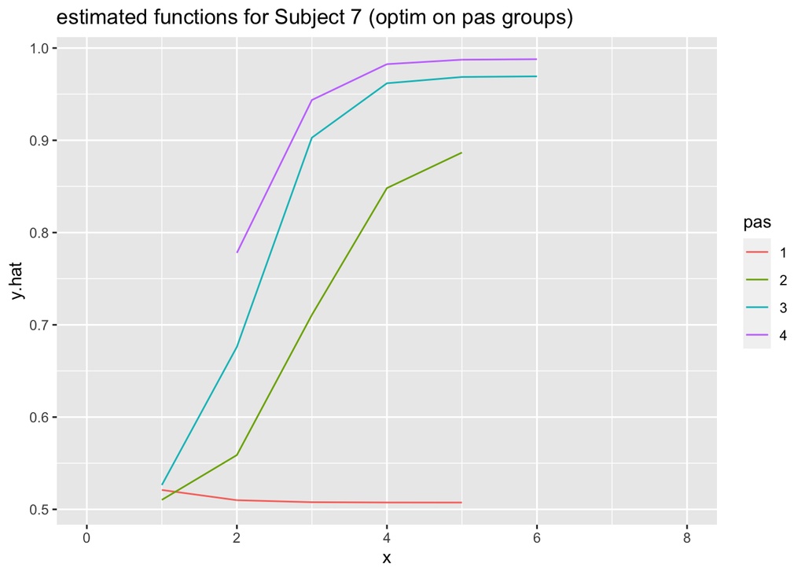

```r
s7.p1 <- data.frame(x = dataset.sub7.p1$x, y.hat = y.hat.p1, pas = as.factor(1))
s7.p2 <- data.frame(x = dataset.sub7.p2$x, y.hat = y.hat.p2, pas = as.factor(2))
s7.p3 <- data.frame(x = dataset.sub7.p3$x, y.hat = y.hat.p3, pas = as.factor(3))
s7.p4 <- data.frame(x = dataset.sub7.p4$x, y.hat = y.hat.p4, pas = as.factor(4))

subject7 <- rbind(s7.p1, s7.p2, s7.p3, s7.p4)

ggplot(subject7, aes(x = x, y = y.hat, color = pas)) +
  geom_line()+
  xlim(0,8)+
  labs(title = 'estimated functions for Subject 7 (optim on pas groups)')
```

**iii. Create a similar plot for the PAS ratings on a single plot (for subject 7), but this time based on the model from 6.1 `xlim=c(0, 8)`**

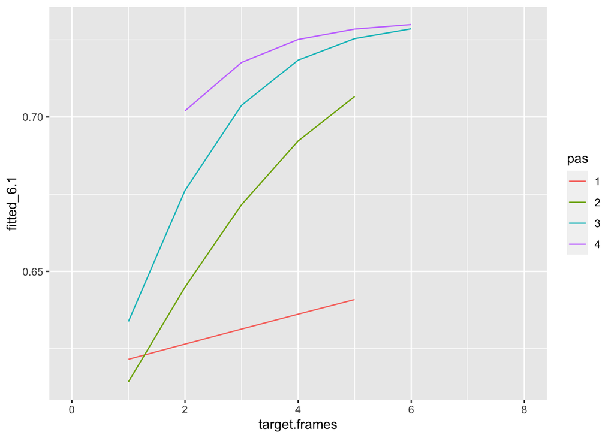

```r
df_new <- df
df_new$fitted_6.1 <- inv.logit(fitted.values(pas.intact.tf.ranslopeint.with.corr))

df_new_sub7 <- df_new %>%
  filter(subject== '7')


ggplot(df_new_sub7, aes(target.frames, fitted_6.1, color = pas)) +
  geom_line() +
  xlim(0, 8)
```

#### 2) Finally, estimate the parameters for all subjects and each of their four PAS ratings. Then plot the estimated function at the group-level by taking the mean for each of the four parameters, *a*, *b*, *c* and *d* across subjects. A function should be estimated for each PAS-rating (it should look somewhat similar to Fig. 3 from the article: https://doi.org/10.1016/j.concog.2019.03.007)

```r
input_df <- data.frame()
count(dataset)
```

| n |
| --- |
| 25044 |

```r
n <- length(unique(dataset$subject))

for (i in 1:n) {
  subject = i
  df_subject <- dataset %>%
    filter(subject == i)

  for(num in 1:4){
    df_pas <- df_subject %>%
      filter(pas == num)
    optim_output <- optim(par = c(0.5, 1, 1, 1),
                      fn = my_rss_function,
                      data = df_pas,
                      method = c("L-BFGS-B"),
                      lower = c(0.5, 0.5, -Inf, -Inf),
                      upper = c(1 ,1, Inf, Inf)
                      )
    par <- optim_output$par
    par_df <- data.frame(a = par[1], b = par[2], c = par[3], d = par[4], subject = subject, pas = num)
    input_df <- rbind(input_df, par_df)
  }
}

input_df
```

| a | b | c | d | subject | pas |
| --- | --- | --- | --- | --- | --- |
| 0.5000000 | 0.5000000 | 1.8101434 | 1.6093584798 | 1 | 1 |
| 0.5730269 | 0.9153299 | 3.8864164 | 0.0069243580 | 1 | 2 |
| 0.7500000 | 0.9720280 | 3.2048574 | 0.0031141604 | 1 | 3 |
| 1.0000000 | 0.9285714 | 5.4651253 | -0.0164825442 | 1 | 4 |
| 0.6053770 | 0.5000000 | 0.9450045 | 0.7108233777 | 2 | 1 |
| 0.5000000 | 0.7727273 | 2.0954288 | 0.0038277764 | 2 | 2 |
| 0.5000000 | 0.9850633 | 2.8823419 | 0.0785004256 | 2 | 3 |
| 0.6999647 | 0.9719069 | 2.8473163 | 0.0550683444 | 2 | 4 |
| 0.6676498 | 0.5376748 | 0.5699980 | 0.4552282759 | 3 | 1 |
| 0.5000000 | 0.5762592 | 1.1125920 | 0.0080890501 | 3 | 2 |

[output cut: 106 more lines]

```r
sum_mean <- input_df %>%
  group_by(pas) %>%
  summarise(a = mean(a), b = mean(b), c = mean(c), d = mean(d))
```

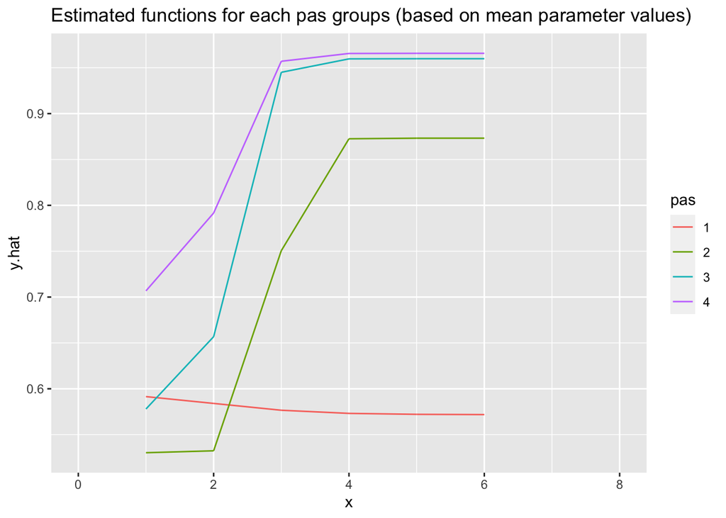

```r
m.par.1 <- c(sum_mean$a[1], sum_mean$b[1], sum_mean$c[1], sum_mean$d[1])
m.par.2 <- c(sum_mean$a[2], sum_mean$b[2], sum_mean$c[2], sum_mean$d[2])
m.par.3 <- c(sum_mean$a[3], sum_mean$b[3], sum_mean$c[3], sum_mean$d[3])
m.par.4 <- c(sum_mean$a[4], sum_mean$b[4], sum_mean$c[4], sum_mean$d[4])

y.hat.p1 <- y_hat_fun(dataset.p1$x, m.par.1)
y.hat.p2 <- y_hat_fun(dataset.p2$x, m.par.2)
y.hat.p3 <- y_hat_fun(dataset.p3$x, m.par.3)
y.hat.p4 <- y_hat_fun(dataset.p4$x, m.par.4)

m.p1 <- data.frame(x = dataset.p1$x, y.hat = y.hat.p1, pas = as.factor(1))
m.p2 <- data.frame(x = dataset.p2$x, y.hat = y.hat.p2, pas = as.factor(2))
m.p3 <- data.frame(x = dataset.p3$x, y.hat = y.hat.p3, pas = as.factor(3))
m.p4 <- data.frame(x = dataset.p4$x, y.hat = y.hat.p4, pas = as.factor(4))

m.all <- rbind(m.p1, m.p2, m.p3, m.p4)

ggplot(m.all, aes(x = x, y = y.hat, color = pas)) +
  geom_line()+
  xlim(0,8)+
  labs(title = 'Estimated functions for each pas groups (based on mean parameter values)')
```

**i. Compare with the figure you made in 5.3.ii and comment on the differences between the fits - mention some advantages and disadvantages of both.**

For both plots, we see similar patterns - except for PAS 1, because all individual subjects are visualized, we see clear individual differences. However, this can be said to be summarized in the Sigmoid Function, where we see no effect of objective evidence. In the Sigmoid function, we get one estimate based on the individual differences. This would not have been the case for a complete pooling model. Opposite to the partial pooling model in 6.1, we still only get one set of parameters for each PAS, which can be easier to interpret than estimates for both for each PAS and subjects. However, having individual slopes for each subject allows us to see individual differences, whereas a mean value does not reveal individual patterns. With a mean, extremes will also affect the parameters to a higher extent, e.g. if the majority of participants had an increase of accuracy for each increase in *target.frames* in PAS 1, but a few subjects had a large decrease, the mean will not reflect no effect. In the model 6.1, we will be able to detect these.